# BIOS 611 Project 3

Christina Zhou

12/1/2019

## Introduction

Urban Ministries of Durham (UMD) is a non-profit organization that serves its community by offering servies that help reduce the rate of homelessness in Durham, NC. The website for UMD is www.umdurham.org. One service UMD offers is shelter. This service is meant to provide struggling individuals or families with a safe place to stay until they are able to get on their own. In the meantime, UMD provides resources to help this happen, such as helping with finding jobs or providing professional clothes for interviews, etc.

## Data Cleaning

There is a lot of data from UMD regarding who enters and exits the shelter resource of the organization. This data identifies each individual as a client, and records one’s age, gender, ethnicity, race, entry and exit dates, and reasons for leaving UMD, as well as other data collection. For this project, we focus on any association between duration of stay at UMD and gender, race, ethnicity, and age at entry. We define duration of stay as number of nights spent at UMD, calculated from the date of entry and the date of exit. We merge the two datasets and preprocess the two datasets in python. For this project, we remove any data with missing data, since the fraction of those with any missing data is less than 1%. In the end, we have a total of 5189 observations.

## Exploratory Analysis

In the section below, we look at different plots of the exploratory variables (age at entry, gender, ethnicity, and race) to get an idea of how the data looks.

```r
dat_noID = dat[,-c(1,2,3,4)]
summary(dat_noID)
```

```
##  Client.Age.at.Entry                              Client.Gender
##  Min.   :18.00       Female                              :1260
##  1st Qu.:35.00       Male                                :3912
##  Median :46.00       Trans Female (MTF or Male to Female):  17
##  Mean   :44.15
##  3rd Qu.:54.00
##  Max.   :81.00
##
##                                       Client.Primary.Race
##  Black or African American (HUD)                :3797
##  White (HUD)                                    :1281
##  American Indian or Alaska Native (HUD)         :  84
##  Native Hawaiian or Other Pacific Islander (HUD):  10
##  Data not collected (HUD)                       :   6
##  Client refused (HUD)                           :   5
##  (Other)                                        :   6
##                       Client.Ethnicity      Entry.Date        Exit.Date
##  Client doesn't know (HUD)    :   8    8/15/2015 : 115   8/14/2015 : 116
##  Client refused (HUD)         :   8    7/6/2015  :  22   3/5/2015  :  22
##  Data not collected (HUD)     :  13    3/14/2016 :  21   5/1/2015  :  22
##  Hispanic/Latino (HUD)        : 186    4/11/2016 :  21   12/12/2016:  21
##  Non-Hispanic/Non-Latino (HUD):4974    12/31/2014:  20   1/3/2017  :  18
##                                        4/6/2015  :  20   12/1/2016 :  18
##                                        (Other)   :4970   (Other)   :4972
##                                        Reason.for.Leaving
##  Other                                          :2456
##  Unknown/Disappeared                            :1179
##  Completed program                              : 522
##  Left for housing opp. before completing program: 450
##  Non-compliance with program                    : 317
##  Needs could not be met                         : 106
##  (Other)                                        : 159
##         Entry              Exit       Total.Nights
##  2015-08-15: 115   2015-08-14: 116   Min.   :  0.00
##  2015-07-06:  22   2015-03-05:  22   1st Qu.:  5.00
##  2016-03-14:  21   2015-05-01:  22   Median : 16.00
##  2016-04-11:  21   2016-12-12:  21   Mean   : 39.61
##  2014-12-31:  20   2016-08-29:  18   3rd Qu.: 45.00
##  2015-04-06:  20   2016-12-01:  18   Max.   :894.00
##  (Other)   :4970   (Other)   :4972
```

```r
dat %>% group_by(Client.Gender) %>%
  summarise(c = n())
```

```
## # A tibble: 3 x 2
##   Client.Gender                            c
##   <fct>                                <int>
## 1 Female                                1260
## 2 Male                                  3912
## 3 Trans Female (MTF or Male to Female)    17
```

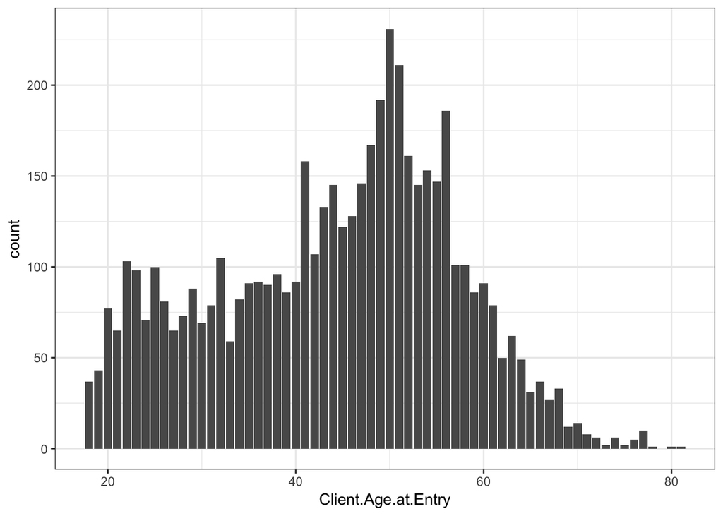

```r
dat %>%
  ggplot(aes(x=Client.Age.at.Entry)) +
  geom_bar() +
  theme(axis.text.x = element_text(angle = 45, hjust = 1))+theme_bw()
```

[figure not shown]

```r
dat %>%
  ggplot(aes(x=Client.Primary.Race)) +
  geom_bar() +
  theme(axis.text.x = element_text(angle = 45, hjust = 1))+theme_bw()
```

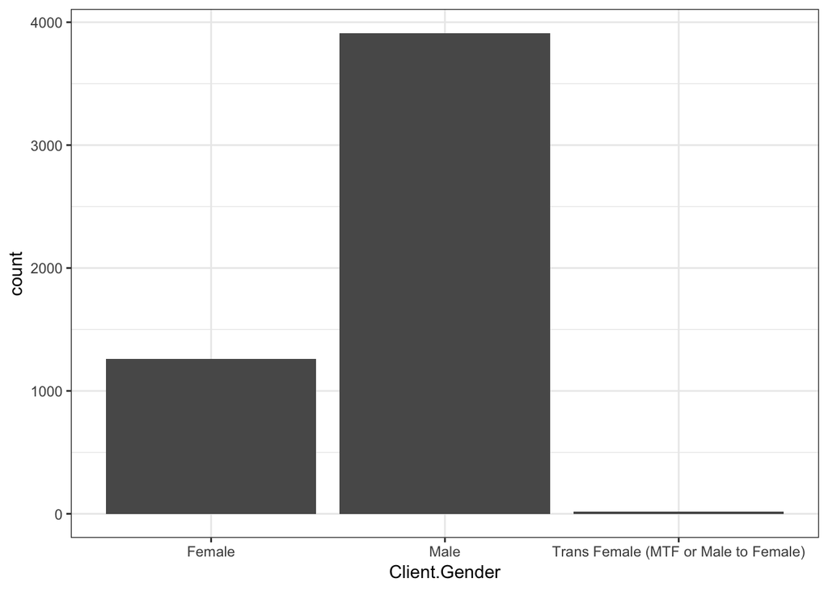

```r
dat %>%
  ggplot(aes(x=Client.Gender)) +
  geom_bar() +
  theme(axis.text.x = element_text(angle = 45, hjust = 1))+theme_bw()
```

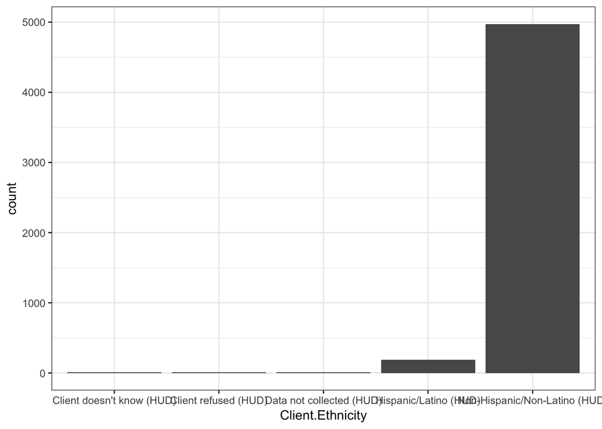

```r
dat %>%
  ggplot(aes(x=Client.Ethnicity)) +
  geom_bar() +
  theme(axis.text.x = element_text(angle = 45, hjust = 1))+theme_bw()
```

Below is a plot of comparison of age at entry by gender.

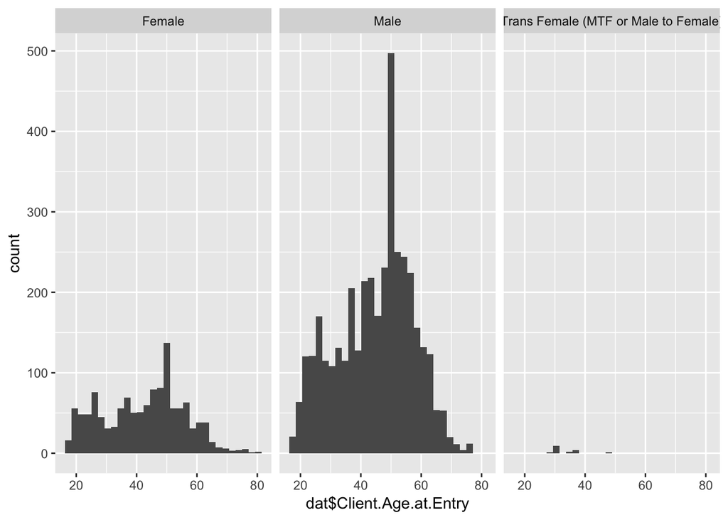

## Analysis

```
##
## Call:
## lm(formula = Total.Nights ~ Client.Gender + Client.Age.at.Entry +
##     Client.Ethnicity + Client.Primary.Race, data = dat)
##
## Residuals:
##    Min     1Q Median     3Q    Max
## -57.34 -33.42 -21.77   6.02 851.83
##
## Coefficients:
##                                                                    Estimate
## (Intercept)                                                        -1.43830
## Client.GenderMale                                                  -6.81117
## Client.GenderTrans Female (MTF or Male to Female)                  -7.16275
## Client.Age.at.Entry                                                 0.54056
## Client.EthnicityClient refused (HUD)                                3.73429
## Client.EthnicityData not collected (HUD)                            3.12751
## Client.EthnicityHispanic/Latino (HUD)                              14.18406
## Client.EthnicityNon-Hispanic/Non-Latino (HUD)                      25.24762
## Client.Primary.RaceAsian (HUD)                                     24.65881
## Client.Primary.RaceBlack or African American (HUD)                 -1.85274
## Client.Primary.RaceClient doesn't know (HUD)                       32.49336
## Client.Primary.RaceClient refused (HUD)                            10.40264
## Client.Primary.RaceData not collected (HUD)                        25.58688
## Client.Primary.RaceNative Hawaiian or Other Pacific Islander (HUD) -7.31339
## Client.Primary.RaceWhite (HUD)                                     -4.42351
##                                                                    Std. Error
## (Intercept)                                                          23.29258
## Client.GenderMale                                                     2.04658
## Client.GenderTrans Female (MTF or Male to Female)                    15.26159
## Client.Age.at.Entry                                                   0.06825
## Client.EthnicityClient refused (HUD)                                 36.07521
## Client.EthnicityData not collected (HUD)                             28.07412
## Client.EthnicityHispanic/Latino (HUD)                                22.63847
## Client.EthnicityNon-Hispanic/Non-Latino (HUD)                        22.11047
## Client.Primary.RaceAsian (HUD)                                       36.70571
## Client.Primary.RaceBlack or African American (HUD)                    6.89022
## Client.Primary.RaceClient doesn't know (HUD)                         36.83532
## Client.Primary.RaceClient refused (HUD)                              36.74504
## Client.Primary.RaceData not collected (HUD)                          26.81807
```

[output cut: 41 more lines]

```
## Client.EthnicityHispanic/Latino (HUD)
## Client.EthnicityNon-Hispanic/Non-Latino (HUD)
## Client.Primary.RaceAsian (HUD)
## Client.Primary.RaceBlack or African American (HUD)
## Client.Primary.RaceClient doesn't know (HUD)
## Client.Primary.RaceClient refused (HUD)
## Client.Primary.RaceData not collected (HUD)
## Client.Primary.RaceNative Hawaiian or Other Pacific Islander (HUD)
## Client.Primary.RaceWhite (HUD)
## ---
## Signif. codes:  0 '***' 0.001 '**' 0.01 '*' 0.05 '.' 0.1 ' ' 1
##
## Residual standard error: 62.44 on 5174 degrees of freedom
## Multiple R-squared:  0.01596,    Adjusted R-squared:  0.0133
## F-statistic: 5.994 on 14 and 5174 DF,  p-value: 6.748e-12
```